# create_seasonality_archetypes_BDI

Monique Ambrose

February 2021

# 1 Introduction

## 1.2 This document

This document walks through the steps taken to perform the clustering, form curating the input files, to generating clusters, to exploring the values of variables in each cluster.

1. Prepare raster layers (input variables), admin shapefile, and calculate mean values in each admin

```
* Create shapefile for health districts with the same CRS as input rasters
* Standardize projection and resolution (align pixels) for all raster layers
* Find (unweighted) mean variable values among all pixels in an admin
* Rescale variable according to the importance/weight we want it to have when clusters are formed
```

2. Run clustering algorithm
3. Explore clustering results

# 2 Setup and file locations

- Code

- Git repo [here](https://github.com/numalariamodeling/hbhi-spatial-clustering)

- Input raster files

- Saved directly in subdirectories of Dropbox (IDM)/Malaria Team Folder/projects/burundi_hbhi/SpatialClustering/input_layers (https://www.dropbox.com/home/Malaria%20Team%20Folder/projects/burundi_hbhi/SpatialClustering/input_layers)
  - Rainfall and tsi rasters from Amelia’s folder in Dropbox: Malaria Team Folder/projects/map_intervention_impact/seasonal_classification/africa/rasters
  - Vector, travel time to city, ITN coverage, and PfPR(2-10) rasters downloaded from [MAP’s website](https://map.ox.ac.uk/explorer/#/) July 2019.

- Input shape files

- Country and admin borders: Dropbox (IDM)/Malaria Team Folder/projects/burundi_hbhi/shapefiles_rasterfiles/bdi_adm_igebu_ocha/bdi_admbnda_adm2_igebu_ocha_20171103.shp (https://www.dropbox.com/home/Malaria%20Team%20Folder/projects/burundi_hbhi/shapefiles_rasterfiles)

- Directory setup for raster file inputs and clustering results

Within a directory named SpatialClustering, subdirectories must be as follows:

- aligned_layers
- clustering_results
- input_layers - must have one subdirectory for each variable type, each of which must contain relevant rasters
  - rain
  - tsi
  - vector
- unscaled_layers

# 3 Prepare boundary shapefiles and raster layers

## 3.1 Admin shapefile

Transform existing shapefile with admin borders so that it has the same CRS as the raster files that will be used as clustering variables

```r
# - - - - - - - - - - - - - - - - - - - - - - - - - - - - - - - - - - - - #
# -                               Setup                                 - #
# - - - - - - - - - - - - - - - - - - - - - - - - - - - - - - - - - - - - #

library(rgdal)
library(raster)
library(stats)
library(viridis)
library(factoextra)


#=============================================================================#
############               USER SPECIFIED INPUTS                 ##############
#=============================================================================#

# set base filepaths
base_filepath_scripts = 'C:/Users/moniqueam/Documents/malaria-snt-core/archetype_clustering'
base_filepath_project = 'C:/Users/moniqueam/Dropbox (IDM)/Malaria Team Folder/projects/burundi_hbhi/snt_2023'
base_filepath_raster = paste0(base_filepath_project, '/SpatialClustering')
ds_shapefile_unprojected_filepath = paste0(base_filepath_raster, '/input_shapefiles/admin_shp/District Sanitaire Burundi.shp')
unmasked_reference_raster_filename = paste(base_filepath_raster, '/input_layers/rain/rainfall_month_01.tif', sep='')

# specify the name of shapefile's attribute that identifies the name of the districts/admin2s (or whatever admin level is being used for clustering)
admin_attribute_name = 'NOM_DS'  # 'NOMDEP'
region_attribute_name = 'PROVINCE' # 'NOMREGION'

overwrite_file_flag = FALSE
# determine whether aligned/scaled rasters should be overwritten if they already exist
overwrite_raster_flag = FALSE
# specify the maximum number of clusters to create (e.g. for elbow plot)
max_num_clusters = 10
# specify whether routine case surveillance data is available and appropriately formatted
case_data_available = FALSE

# specify variable types to be included in determining archetypes (to change weights, see section below)
# options are
#   'climate_vector' - create archetypes based on climate and vector
#   'climate_vector_proximity' - create archetypes based on climate, vector, and admin proximity to one another
#   'climate_vector_proximity_pre2010itn'
#   'climate_vector_proximity_pre2010itn_MIS2016'
#   'case_seasonality' - use the seasonality patterns of (rescaled) cases in each DS to create archetypes  NOTE: this will only be supported after we get the routine surveillance data
#   'climate_vector_proximity_pre2010itn_caseSeasonality'
clustering_type = 'climate_vector_proximity_pre2010itn'

#=============================================================================#

setwd(base_filepath_scripts)

reference_raster_filename = paste(base_filepath_raster, '/reference_rasters_shapefiles/cropped_projection_reference.tif', sep='')
ds_shapefile_filepath = paste0(base_filepath_raster, '/reference_rasters_shapefiles/bdi_adm2.shp')





# - - - - - - - - - - - - - - - - - - - - - - - - - - - - - - - - - - - - - - - - - - - - #
# -   Create output directories for this project if they do not already exist    - #
# - - - - - - - - - - - - - - - - - - - - - - - - - - - - - - - - - - - - - - - - - - - - #
if (!dir.exists(paste0(base_filepath_raster, '/aligned_layers')))  dir.create(paste0(base_filepath_raster, '/aligned_layers'))
if (!dir.exists(paste0(base_filepath_raster, '/clustering_results'))) dir.create(paste0(base_filepath_raster, '/clustering_results'))
if (!dir.exists(paste0(base_filepath_raster, '/unscaled_layers'))) dir.create(paste0(base_filepath_raster, '/unscaled_layers'))
if (!dir.exists(paste0(base_filepath_raster, '/reference_rasters_shapefiles'))) dir.create(paste0(base_filepath_raster, '/reference_rasters_shapefiles'))
if (!dir.exists(paste0(base_filepath_raster, '/input_layers/centroid'))) dir.create(paste0(base_filepath_raster, '/input_layers/centroid'))


# - - - - - - - - - - - - - - - - - - - - - - - - - - - - - - - - - - - - - - - - - - - - #
# -   Prepare reference raster and shapefile with appropriate projection and masking    - #
# - - - - - - - - - - - - - - - - - - - - - - - - - - - - - - - - - - - - - - - - - - - - #
# check whether the file already exists
if ((!file.exists(ds_shapefile_filepath)) | (!file.exists(reference_raster_filename))){
  # read in DS shapefile with different projection than raster files
  ds_shapefile_unprojected = shapefile(ds_shapefile_unprojected_filepath)
  # change the shapefile's admin attribute name to 'NOMDEP' so that it is referenced correctly in this script
  names(ds_shapefile_unprojected)[names(ds_shapefile_unprojected) == admin_attribute_name] = 'NOMDEP'
  names(ds_shapefile_unprojected)[names(ds_shapefile_unprojected) == region_attribute_name] = 'NOMREGION'
  # read in one of the input raster files (projection and resolution will be used for all future rasters/shapefiles)
  unmasked_raster = raster(unmasked_reference_raster_filename)
  # need to reproject shapefile so that it will have the same projection as the reference raster
  ds_shapefile = spTransform(ds_shapefile_unprojected, crs(unmasked_raster))
  # save shapefile as country/ds shapefile for all raster creations
  shapefile(ds_shapefile, filename=ds_shapefile_filepath)
  # crop and mask the raster to the current country borders
  cropped_projection_reference = crop(unmasked_raster, ds_shapefile)
  cropped_projection_reference = mask(cropped_projection_reference, ds_shapefile)
  # save reference raster
  writeRaster(cropped_projection_reference, reference_raster_filename)
}
```

Saves a reference raster and shapefile (to be used for the projection and resolution in future analyses) in reference_rasters_shapefiles folder.

## 3.2 Calculate the mean monthly cases in each DS (if this is available and will be included in clustering)

```r
# only do this if the routine surveillance data is available
if(case_data_available){
  source(paste0(base_filepath_scripts, '/prepare_clustering_inputs/calculate_mean_monthly_cases_each_DS.R'))
  calculate_mean_monthly_cases_each_DS(base_filepath_raster, ds_shapefile_filepath, BF_montly_case_data_filepath, var_weight_string, plot_flag=TRUE, use_susp_flag=TRUE)
}
```

The generated csv and raster files are saved in input_layers/caseSeasonalityDS.

## 3.3 Save latitude and longitude of centroid for each admin

```r
source(paste0(base_filepath_scripts, '/prepare_clustering_inputs/save_admin_centroid_coords.R'))

save_admin_centroids(base_filepath_raster=base_filepath_raster, ds_shapefile_filepath=ds_shapefile_filepath)
```

## 3.4 Specify variables and weights used in clustering

Weights for each variable type:

```
## [1] "vector: 1"
## [1] "rain: 3"
## [1] "tsi: 2"
## [1] "centroid: 2"
## [1] "pre2010itn: 2"
```

## 3.5 Get values of each variable in chiefdoms, taking the mean of all pixels in the chiefdom

Read in, clip, mask, align the rastor files that will serve as the clustering variables. Find the mean variable values among all pixels in the same chiefdom and save results as a csv fileS.

```r
# - - - - - - - - - - - - - - - - - - - - - - - - - - - - - - - - - - - - #
# -               Prepare raster input files                            - #
# - - - - - - - - - - - - - - - - - - - - - - - - - - - - - - - - - - - - #

# load raster-preparation functions
source(paste0(base_filepath_scripts, '/prepare_clustering_inputs/extract_raster_values.R'))

# list of all .tiff files in directories
variable_type_files = list()
for(vv in 1:length(variable_type_names)){
  variable_type_files[[vv]] =  list.files(path=paste(base_filepath_raster, '/input_layers/', variable_type_names[vv], sep=''), pattern="*.{0,3}tiff?", full.names=TRUE, recursive=FALSE)
  # remove any files that contain '.aux.xml'
  remove_indices = grep('.aux.xml', variable_type_files[[vv]])
  if (length(remove_indices)>0){
    variable_type_files[[vv]] = variable_type_files[[vv]][-remove_indices]
  }
}

# read in, clip, mask, align, and weight the rastor files that will serve as the clustering variables
get_mean_ds_value_from_raster(base_filepath_raster=base_filepath_raster,
                    ds_shapefile_filepath=ds_shapefile_filepath,
                    variable_type_names=variable_type_names,
                    variable_type_files=variable_type_files,
                    overwrite_raster_flag=overwrite_raster_flag)
```

Rescale the input variable files to reflect the desired weights

```r
# - - - - - - - - - - - - - - - - - - - - - - - - - - - - - - - - - - - - #
# -                  Rescaled values in each admin                      - #
# - - - - - - - - - - - - - - - - - - - - - - - - - - - - - - - - - - - - #



variable_weights_rescale(base_filepath_raster=base_filepath_raster,
                         variable_type_names=variable_type_names,
                         variable_type_weights=variable_type_weights,
                         variable_type_files=variable_type_files,
                         var_weight_string=var_weight_string,
                         overwrite_raster_flag=overwrite_raster_flag)
```

```
## [1] "finished working on 33 variables/raster layers"
```

```r
# read in dataframe that gives information on the variables, variable types, and weights (csv file created in align_input_rasters() function)
variable_record_df = read.csv(paste(base_filepath_raster, '/aligned_layers/', var_weight_string, '/variable_information.csv', sep=''))

# store vector of unscaled and rescaled ('aligned') raster filenamess - keep in vector in same order as saved in variable_record_df csv file created in align_input_rasters() function
unscaled_files = c()
aligned_files = c()
for(ii in 1:length(variable_record_df[,1])){
  unscaled_files = c(unscaled_files, paste(base_filepath_raster, '/unscaled_layers/', sub('aligned', 'unscaled', variable_record_df$variable_filename_vector[ii]), sep=''))
  aligned_files = c(aligned_files, paste(base_filepath_raster, '/aligned_layers/', var_weight_string, '/', variable_record_df$variable_filename_vector[ii], sep=''))
}
```

# 4 Run clustering algorithm

Use k-means and the CLARA algorithms to perform clustering - repeat with different numbers of total clusters:

```r
source(paste0(base_filepath_scripts, '/prepare_clustering_inputs/cluster_by_DS_mean.R'))
# - - - - - - - - - - - - - - - - - - - - - - - - - - - - - - - - - - - - #
# -                  Clustering at DS level                             - #
# - - - - - - - - - - - - - - - - - - - - - - - - - - - - - - - - - - - - #
num_clusters_vect = 1:max_num_clusters
create_new_clusters_flag = !file.exists(paste(base_filepath_raster, '/clustering_results/', var_weight_string, '/DS_level_clusterResultObject_', 1, 'clusters.RData', sep=''))
if (create_new_clusters_flag){
  kmeans_ss_DS = cluster_DS_means(base_filepath_raster, ds_shapefile_filepath, variable_record_df, var_weight_string, aligned_files, num_clusters_vect)
}
```

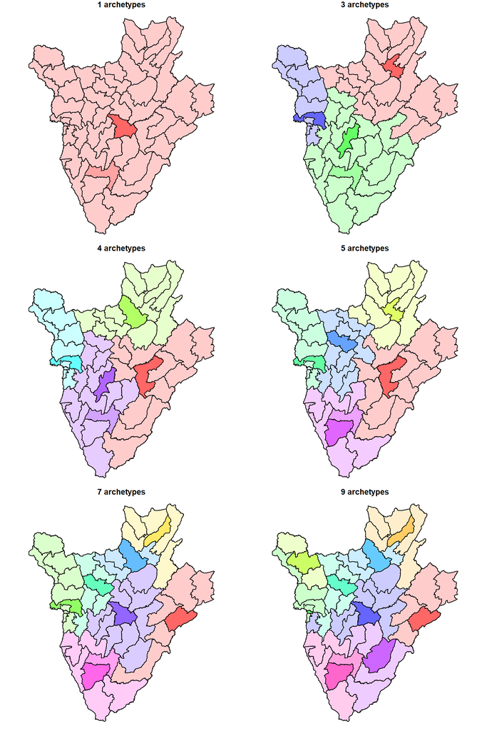

**Clustering results.** CLARA with different numbers of clusters. Each color corresponds to an archetype; the representative DS for each archetype is shown in a darker color.

Representative DS when different numbers of clusters are used:

```r
num_clusters_print = c(3, 4, 7, 9)
for(ii in 1:length(num_clusters_print)){
  # load in clustering output for this number of clusters - kmeans_output and clara_output variables are loaded
  load(paste(base_filepath_raster, '/clustering_results/', var_weight_string, '/DS_level_clusterResultObject_', num_clusters_print[ii], 'clusters.RData', sep=''))

  print(paste('representative DS for ', num_clusters_print[ii], ' archetypes: ', sep=''))
  print(ds_shapefile$NOMDEP[clara_output$i.med])

}
```

```
## [1] "representative DS for 3 archetypes: "
## [1] "Gashoho" "Kibumbu" "Isale"
## [1] "representative DS for 4 archetypes: "
## [1] "Butezi"  "Kiremba" "Isale"   "Kibumbu"
## [1] "representative DS for 7 archetypes: "
## [1] "Gisuru"  "Mukenke" "Isale"   "Musema"  "Kiremba" "Gitega"  "Bururi"
## [1] "representative DS for 9 archetypes: "
## [1] "Gisuru"      "Mukenke"     "Bukinanyana" "Zone Centre" "Musema"
## [6] "Kiremba"     "Gitega"      "Rutana"      "Bururi"
```

## 4.1 Restore original variable values and assign to each cluster

```r
if (create_new_clusters_flag | !file.exists(paste(base_filepath_raster, '/clustering_results/', var_weight_string, '/DS_kmeans_centroids_', num_clusters,'clusters.csv', sep='')) | !file.exists(paste(base_filepath_raster, '/clustering_results/', var_weight_string, '/DS_clara_medoids_', num_clusters,'clusters.csv', sep=''))){
  # load functions for calculating centroid values for each cluster
  source(paste0(base_filepath_scripts, '/explore_clustering_results/restore_raster_values.R'))
  for(i_c in 1:max_num_clusters){
    # load in kmeans output for this number of clusters - kmeans_output and clara_output variables are loaded
    load(paste(base_filepath_raster, '/clustering_results/', var_weight_string, '/DS_level_clusterResultObject_', i_c, 'clusters.RData', sep=''))
    # run function to calculate original/restored variable values for each of the cluster centroids and save as csv
    restore_variable_values(base_filepath_raster, var_weight_string, unscaled_files, variable_record_df, kmeans_output, num_clusters=i_c, clara_output, include_clara_flag=TRUE, pixel_flag = FALSE)
  }

}


num_clusters = 4
# read in results and print a part of the table
clara_medoid_restored_values = read.csv(paste(base_filepath_raster, '/clustering_results/', var_weight_string, '/restored_values_each_cluster/DS_clara_medoids_', num_clusters,'clusters.csv', sep=''))[-1]

# determine which columns to include in printed table
col_indices = c(which(variable_record_df$variable_type_vector=='vector'), which(variable_record_df$variable_type_vector=='rain')[c(4, 10)])
if(grepl('pre2010itn', clustering_type)){
  col_indices = c(col_indices, which(variable_record_df$variable_type_vector=='pre2010itn')[3])
}

print(clara_medoid_restored_values[1:5, unique(sort(col_indices))])
```

```
##    X2016_Anopheles_arabiensis.RelativeAbundance_Decompressed.tiff
## 1                                                      0.09332313
## 2                                                      0.00525946
## 3                                                      0.14233740
## 4                                                      0.00000000
## NA                                                             NA
##    X2016_Anopheles_coluzzii_gambiae.RelativeAbundance_Decompressed.tiff
## 1                                                             0.7150957
## 2                                                             0.8419425
## 3                                                             0.6281414
## 4                                                             0.3372715
## NA                                                                   NA
##    X2016_Anopheles_funestus_subgroup.RelativeAbundance_Decompressed.tiff
## 1                                                              0.1915812
## 2                                                              0.1527980
## 3                                                              0.2295212
## 4                                                              0.6627285
## NA                                                                    NA
##    rainfall_month_04.tif rainfall_month_10.tif ITN_2010.USE.tif
## 1               178.8349              96.42797        0.4255993
## 2               181.8890             138.51095        0.4128956
## 3               169.7876             111.93236        0.4863316
## 4               164.6101             110.18871        0.2419173
## NA                    NA                    NA               NA
```

Creates a csv file clustering_results/{parameter_weighting_of_interest}/DS_kmeans_centroids_{num_clusters}clusters.csv that gives the restored variable value for the centroid of each cluster.

# 5 Explore clustering results

## 5.1 Elbow method

Explore the optimal number of clusters. However, note that for our purposes this is less relevant than making sure that we have enough clusters to appropriately capture all major seasonality patterns in the country.

```r
# - - - - - - - - - - - - - - - - - - - - - - - - - - - - - - - - - - - - #
# -           Elbow method for determining number of clusters           - #
# - - - - - - - - - - - - - - - - - - - - - - - - - - - - - - - - - - - - #
# Calculate how much variance is explained for each number of clusters
pdf_flag=TRUE


if (create_new_clusters_flag){
  # save results in csv file
  kmeans_sum_squares_results = matrix(nrow=3, ncol=length(num_clusters_vect))
  kmeans_sum_squares_results[1,] = kmeans_ss_DS[[1]]  # betweenss_vect
  kmeans_sum_squares_results[2,] = kmeans_ss_DS[[2]]  # sum_withinss_vect
  kmeans_sum_squares_results[3,] = kmeans_ss_DS[[3]]  # totss_vect
  rownames(kmeans_sum_squares_results) = c('between_ss', 'sum_within_ss', 'total_ss')
  colnames(kmeans_sum_squares_results) = num_clusters_vect

  write.csv(kmeans_sum_squares_results, paste(base_filepath_raster, '/clustering_results/', var_weight_string, '/DS_kmeans_elbow_min_', min(num_clusters_vect), '_max', max(num_clusters_vect),'.csv', sep=''))
}

# determine whether to plot kmeans or clara result
plot_clara = TRUE

if(plot_clara){
  # read in dataframe of the weighted variable values for each DS (used in clustering)
  ds_means_df = read.csv(paste(base_filepath_raster, '/aligned_layers/', var_weight_string, '/mean_rescaled_values_each_DS.csv', sep=''))[,-1]

   if(pdf_flag){
    pdf_filename = paste(base_filepath_raster, '/clustering_results/', var_weight_string, '/figures/optimal_number_clusters_clara.pdf', sep='')
    pdf(pdf_filename, width=6, height=4)
  }

  # create three plots: one for each of the methods to find the optimal number of clusters
  fviz_nbclust(as.matrix(ds_means_df[,-1]), clara, method = "wss", k.max=max(num_clusters_vect)) +
    labs(subtitle = "Elbow method")
  # fviz_nbclust(as.matrix(ds_means_df[,-1]), clara, method = "silhouette", k.max=max(num_clusters_vect)) +
  #   labs(subtitle = "Silhouette method")
  # fviz_nbclust(as.matrix(ds_means_df[,-1]), clara, method = "gap_stat", k.max=max(num_clusters_vect)) +
  #  labs(subtitle = "Gap statistic method")

  if(pdf_flag){
    dev.off()
  }

} else{
  # read in previously-saved results
  kmeans_sum_squares_results = read.csv(paste(base_filepath_raster, '/clustering_results/', var_weight_string, '/DS_kmeans_elbow_min_', min(num_clusters_vect), '_max', max(num_clusters_vect),'.csv', sep=''), header=TRUE)[,-1]
  rownames(kmeans_sum_squares_results) = c('between_ss', 'sum_within_ss', 'total_ss')
  colnames(kmeans_sum_squares_results) = num_clusters_vect

  # create elbow plot to explore optimal number of clusters
  if(pdf_flag){
    pdf_filename = paste(base_filepath_raster, '/clustering_results/', var_weight_string, '/figures/elbow_plot_kmeans.pdf', sep='')
    pdf(pdf_filename, width=10, height=6)
  }
  plot(num_clusters_vect, (kmeans_sum_squares_results[1,] / kmeans_sum_squares_results[3,]), type='b', bty='L', ylab='between SS / total SS', xlab='number of clusters')
  if(pdf_flag){
    dev.off()
  }
}
```

## 5.2 Compare original variable values with clustered values

```r
# - - - - - - - - - - - - - - - - - - - - - - - - - - - - - - - - - - - - #
# -   Plot comparison of original variable layers and clustered values  - #
# - - - - - - - - - - - - - - - - - - - - - - - - - - - - - - - - - - - - #
source(paste0(base_filepath_scripts, '/explore_clustering_results/compare_variables_original_DS_clustering.R'))
#
# # calculate origina, DS-mean, and clustered pixel values for all variables
# compare_variables_original_DS_clustering(base_filepath_raster, ds_shapefile_filepath, var_weight_string, unscaled_files, variable_record_df, num_clusters, plot_flag=TRUE, pdf_flag=TRUE, subset_plot_indices=c())
#
# # plot pixel values and difference between true and clustered pixel values
# plot_error_DS_clustering(base_filepath_raster, var_weight_string, num_clusters, pdf_flag=TRUE, show_error_flag=FALSE, subset_plot_indices=col_indices)
```

### 5.2.1 Look at difference between original admin values and values after clustering for different numbers of clusters

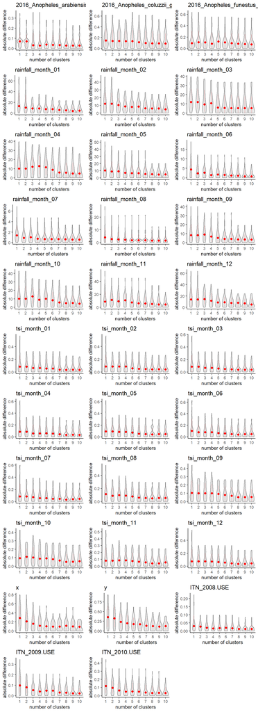

```r
# - - - - - - - - - - - - - - - - - - - - - - - - - - - - - - - - - - - - - - - - - - - - - - - - - #
# -   Plot violin plot of differences between original variable layers and clustered values  - #
# - - - - - - - - - - - - - - - - - - - - - - - - - - - - - - - - - - - - - - - - - - - - - - - - - #
violin_plot_clust_error(base_filepath_raster=base_filepath_raster, var_weight_string=var_weight_string, max_num_clust=max_num_clusters)
```

Pdf saved with violin plots of absolute difference between original and clustered values in each admin.

## 5.3 Examine whether monthly case patterns are consistent within an archetype (if the routine case data for this country are available and appropriately formatted)

### 5.3.1 3 clusters

```r
# only do this if the routine surveillance data is available
if(case_data_available){
  num_clusters = 3
  # load in clustering output for this number of clusters - kmeans_output and clara_output variables are loaded
  load(paste(base_filepath_raster, '/clustering_results/', var_weight_string, '/DS_level_clusterResultObject_', num_clusters, 'clusters.RData', sep=''))

  pdf_filename = paste(base_filepath_raster, '/clustering_results/', var_weight_string, '/figures/mean_monthly_cases_by_archetype_', num_clusters, 'clusters.pdf', sep='')
  plot_monthly_cases_by_archetype(base_filepath_raster, ds_shapefile_filepath, num_clusters, clara_output, show_susp_flag=TRUE, show_rescaled_flag=TRUE, show_subplots_flag=TRUE, pdf_flag=FALSE, pdf_filename=pdf_filename)
}
```

### 5.3.2 5 clusters

```r
# only do this if the routine surveillance data is available
if(case_data_available){
  num_clusters = 5
  # load in clustering output for this number of clusters - kmeans_output and clara_output variables are loaded
  load(paste(base_filepath_raster, '/clustering_results/', var_weight_string, '/DS_level_clusterResultObject_', num_clusters, 'clusters.RData', sep=''))

  pdf_filename = paste(base_filepath_raster, '/clustering_results/', var_weight_string, '/figures/mean_monthly_cases_by_archetype_', num_clusters, 'clusters.pdf', sep='')
  plot_monthly_cases_by_archetype(base_filepath_raster, ds_shapefile_filepath, num_clusters, clara_output, show_susp_flag=TRUE, show_rescaled_flag=TRUE, show_subplots_flag=TRUE, pdf_flag=FALSE, pdf_filename=pdf_filename)
}
```

### 5.3.3 8 clusters

```r
# only do this if the routine surveillance data is available
if(case_data_available){
  num_clusters = 8
  # load in clustering output for this number of clusters - kmeans_output and clara_output variables are loaded
  load(paste(base_filepath_raster, '/clustering_results/', var_weight_string, '/DS_level_clusterResultObject_', num_clusters, 'clusters.RData', sep=''))


  pdf_filename = paste(base_filepath_raster, '/clustering_results/', var_weight_string, '/figures/mean_monthly_cases_by_archetype_', num_clusters, 'clusters.pdf', sep='')
  plot_monthly_cases_by_archetype(base_filepath_raster, ds_shapefile_filepath, num_clusters, clara_output, show_susp_flag=TRUE, show_rescaled_flag=TRUE, show_subplots_flag=TRUE, pdf_flag=FALSE, pdf_filename=pdf_filename)
}
```

### 5.3.4 Compare DHS values within a district versus within an archetype

```r
source(paste0(base_filepath_scripts, '/explore_clustering_results/DHS_results_by_cluster_versus_by_district.R'))
# in the left column, plot difference between each cluster value and mean across all clusters in the same district or in the same archetype. point size shows number of participants in cluster. Show archetype results with both num_clusters=num_districts and num_clusters=30
# in the right column, plot the number of individuals included in the survey in each of the districts/archetypes
#
# MIS_2016_filename = paste0(base_filepath_project, '/explore_DHS/MIS_2016.csv')
# chiefdom_colname=admin_attribute_name
# district_colname=region_attribute_name
# cluster_ids_each_DS_filename = paste0(base_filepath_raster, '/clustering_results/', var_weight_string, '/clusters_by_DS_mean_variable.csv')
# num_clusters = max_num_clusters
# pdf_filename=paste0(base_filepath_raster, '/clustering_results/', var_weight_string, '/figures/DHS_observation_versus_district_cluster_mean.pdf')
#
# get_survey_versus_mean_dhs_values(MIS_2016_filename, chiefdom_colname, district_colname, cluster_ids_each_DS_filename, num_clusters,pdf_filename)
```